# wrangle_act

## Dog Ratings - Wrangling, Analysis, Visualizations

Created: 10/20/2018  
Latest Update: 10/23/2018  
By: Can Bekleyici - bekleydata.com

- Introduction
- Part I - Gathering
- Part II - Assessing the Data
- Part IIIa - Cleaning (tidiness)
- Part IIIb - Cleaning (quality)
- Part IV - Exploratory Data Analysis
- Part Va - Asking Questions
- Part Vb - Additional Visualizations

### Introduction

This project aims to to get insightful information about dog ratings from the twitter page WeRateDogs™, while demonstrating advanced data wrangling and visualization techniques using various Python libraries. WeRateDogs™ is a community page on twitter designated to rating dogs on their appearences and stories, and which was formed by the user @dog_rates in 2015. The page has since grown extremely in popularity, with many users sharing its content and requesting their dogs being rated aswell. The site is a driving force for the development of the 'dog culture', with it's famous terms like "pupper", "mlem", "floof" etc. They also developed their own unusual rating system over time, in which almost every dog is rated above 10/10, because "they're good dogs".

# Part I - Gathering

```python
# import packages
import pandas as pd
import numpy as np
import requests
import tweepy as tp
import json
```

```python
# load csv file into df
df = pd.read_csv('twitter-archive-enhanced.csv')
df.head()
```

|  | tweet_id | in_reply_to_status_id | in_reply_to_user_id | timestamp | source | text | retweeted_status_id | retweeted_status_user_id | retweeted_status_timestamp | expanded_urls | rating_numerator | rating_denominator | name | doggo | floofer | pupper | puppo |
| --- | --- | --- | --- | --- | --- | --- | --- | --- | --- | --- | --- | --- | --- | --- | --- | --- | --- |
| 0 | 892420643555336193 | NaN | NaN | 2017-08-01 16:23:56 +0000 | <a href="http://twitter.com/download/iphone" r... | This is Phineas. He's a mystical boy. Only eve... | NaN | NaN | NaN | https://twitter.com/dog_rates/status/892420643... | 13 | 10 | Phineas | None | None | None | None |
| 1 | 892177421306343426 | NaN | NaN | 2017-08-01 00:17:27 +0000 | <a href="http://twitter.com/download/iphone" r... | This is Tilly. She's just checking pup on you.... | NaN | NaN | NaN | https://twitter.com/dog_rates/status/892177421... | 13 | 10 | Tilly | None | None | None | None |
| 2 | 891815181378084864 | NaN | NaN | 2017-07-31 00:18:03 +0000 | <a href="http://twitter.com/download/iphone" r... | This is Archie. He is a rare Norwegian Pouncin... | NaN | NaN | NaN | https://twitter.com/dog_rates/status/891815181... | 12 | 10 | Archie | None | None | None | None |
| 3 | 891689557279858688 | NaN | NaN | 2017-07-30 15:58:51 +0000 | <a href="http://twitter.com/download/iphone" r... | This is Darla. She commenced a snooze mid meal... | NaN | NaN | NaN | https://twitter.com/dog_rates/status/891689557... | 13 | 10 | Darla | None | None | None | None |
| 4 | 891327558926688256 | NaN | NaN | 2017-07-29 16:00:24 +0000 | <a href="http://twitter.com/download/iphone" r... | This is Franklin. He would like you to stop ca... | NaN | NaN | NaN | https://twitter.com/dog_rates/status/891327558... | 12 | 10 | Franklin | None | None | None | None |

```python
# download 'image-predictions.tsv'
r = requests.get('https://d17h27t6h515a5.cloudfront.net/topher/2017/August/599fd2ad_image-predictions/image-predictions.tsv')
with open('image-predictions.tsv', mode='wb') as file:
    file.write(r.content)
```

```python
# read 'image-predictions.tsv' in a df
df2 = pd.read_csv('image-predictions.tsv', sep='\t')
df2.head()
```

|  | tweet_id | jpg_url | img_num | p1 | p1_conf | p1_dog | p2 | p2_conf | p2_dog | p3 | p3_conf | p3_dog |
| --- | --- | --- | --- | --- | --- | --- | --- | --- | --- | --- | --- | --- |
| 0 | 666020888022790149 | https://pbs.twimg.com/media/CT4udn0WwAA0aMy.jpg | 1 | Welsh_springer_spaniel | 0.465074 | True | collie | 0.156665 | True | Shetland_sheepdog | 0.061428 | True |
| 1 | 666029285002620928 | https://pbs.twimg.com/media/CT42GRgUYAA5iDo.jpg | 1 | redbone | 0.506826 | True | miniature_pinscher | 0.074192 | True | Rhodesian_ridgeback | 0.072010 | True |
| 2 | 666033412701032449 | https://pbs.twimg.com/media/CT4521TWwAEvMyu.jpg | 1 | German_shepherd | 0.596461 | True | malinois | 0.138584 | True | bloodhound | 0.116197 | True |
| 3 | 666044226329800704 | https://pbs.twimg.com/media/CT5Dr8HUEAA-lEu.jpg | 1 | Rhodesian_ridgeback | 0.408143 | True | redbone | 0.360687 | True | miniature_pinscher | 0.222752 | True |
| 4 | 666049248165822465 | https://pbs.twimg.com/media/CT5IQmsXIAAKY4A.jpg | 1 | miniature_pinscher | 0.560311 | True | Rottweiler | 0.243682 | True | Doberman | 0.154629 | True |

```python
# connect to the twitter api
consumer_key = 'xxxx xxxx xxxx xxxx'
consumer_secret = 'xxxx xxxx xxxx xxxx'
access_token = 'xxxx xxxx xxxx xxxx'
access_secret = 'xxxx xxxx xxxx xxxx'

auth = tp.OAuthHandler(consumer_key, consumer_secret)
auth.set_access_token(access_token, access_secret)

api = tp.API(auth, wait_on_rate_limit = True, wait_on_rate_limit_notify = True)
```

```python
# retreives a list of dictionaries from the twitter api, with informations about each tweets id, favorite count, and retweet count
df_list = []
errors = []
for id in df['tweet_id']:
    try:
        tweet = api.get_status(id, tweet_mode='extended')
        df_list.append({'tweet_id': str(tweet.id),
                        'favorite_count': int(tweet.favorite_count),
                        'retweet_count': int(tweet.retweet_count)})
    except Exception as e:
        print(str(id) + " : " + str(e))
        errors.append(id)
```

```python
# returns the number of unretreivable id's
len(errors)
```

```python
# saves the list of dictionaries in a json formatted txt file
with open('tweet_json.txt', 'w') as outfile:
    json.dump(df_list, outfile)
```

```python
# loads the json file into a dataframe
with open('tweet_json.txt', 'r') as file:
    df3 = pd.DataFrame(json.load(file), columns=['tweet_id', 'favorite_count', 'retweet_count'])
```

```python
df3.head()
```

|  | tweet_id | favorite_count | retweet_count |
| --- | --- | --- | --- |
| 0 | 892420643555336193 | 38302 | 8404 |
| 1 | 892177421306343426 | 32827 | 6196 |
| 2 | 891815181378084864 | 24720 | 4100 |
| 3 | 891689557279858688 | 41634 | 8531 |
| 4 | 891327558926688256 | 39797 | 9249 |

# Part II - Assessing the Data

```python
df.sample(5)
```

|  | tweet_id | in_reply_to_status_id | in_reply_to_user_id | timestamp | source | text | retweeted_status_id | retweeted_status_user_id | retweeted_status_timestamp | expanded_urls | rating_numerator | rating_denominator | name | doggo | floofer | pupper | puppo |
| --- | --- | --- | --- | --- | --- | --- | --- | --- | --- | --- | --- | --- | --- | --- | --- | --- | --- |
| 1224 | 714214115368108032 | NaN | NaN | 2016-03-27 22:14:49 +0000 | <a href="http://twitter.com/download/iphone" r... | Happy Easter from the squad! 🐇🐶 13/10 for all ... | NaN | NaN | NaN | https://twitter.com/dog_rates/status/714214115... | 13 | 10 | None | None | None | None | None |
| 770 | 776819012571455488 | NaN | NaN | 2016-09-16 16:24:19 +0000 | <a href="http://twitter.com/download/iphone" r... | RT @dog_rates: Everybody look at this beautifu... | 6.798284e+17 | 4.196984e+09 | 2015-12-24 00:58:27 +0000 | https://twitter.com/dog_rates/status/679828447... | 13 | 10 | None | None | None | pupper | None |
| 738 | 780800785462489090 | NaN | NaN | 2016-09-27 16:06:28 +0000 | <a href="http://twitter.com/download/iphone" r... | This is Koda. He has a weird relationship with... | NaN | NaN | NaN | https://twitter.com/dog_rates/status/780800785... | 11 | 10 | Koda | None | None | None | None |
| 226 | 848690551926992896 | NaN | NaN | 2017-04-03 00:16:10 +0000 | <a href="http://twitter.com/download/iphone" r... | Please stop sending in animals other than dogs... | NaN | NaN | NaN | https://twitter.com/dog_rates/status/848690551... | 12 | 10 | None | None | None | None | None |
| 2257 | 667728196545200128 | NaN | NaN | 2015-11-20 15:36:22 +0000 | <a href="http://twitter.com" rel="nofollow">Tw... | Meet Olive. He comes to spot by tree to remini... | NaN | NaN | NaN | https://twitter.com/dog_rates/status/667728196... | 11 | 10 | Olive | None | None | None | None |

```python
df.info()
```

```
<class 'pandas.core.frame.DataFrame'>
RangeIndex: 2356 entries, 0 to 2355
Data columns (total 17 columns):
tweet_id                      2356 non-null int64
in_reply_to_status_id         78 non-null float64
in_reply_to_user_id           78 non-null float64
timestamp                     2356 non-null object
source                        2356 non-null object
text                          2356 non-null object
retweeted_status_id           181 non-null float64
retweeted_status_user_id      181 non-null float64
retweeted_status_timestamp    181 non-null object
expanded_urls                 2297 non-null object
rating_numerator              2356 non-null int64
rating_denominator            2356 non-null int64
name                          2356 non-null object
doggo                         2356 non-null object
floofer                       2356 non-null object
pupper                        2356 non-null object
puppo                         2356 non-null object
dtypes: float64(4), int64(3), object(10)
memory usage: 313.0+ KB
```

```python
# checking rating denominators
df['rating_denominator'].value_counts()
```

```
10     2333
11        3
50        3
80        2
20        2
2         1
16        1
40        1
70        1
15        1
90        1
110       1
120       1
130       1
150       1
170       1
7         1
0         1
Name: rating_denominator, dtype: int64
```

```python
# checking rating numerators
df['rating_numerator'].value_counts()
```

```
12      558
11      464
10      461
13      351
9       158
8       102
7        55
14       54
5        37
6        32
3        19
4        17
1         9
2         9
420       2
```

[output cut: 26 more lines]

```python
# inspecting the reason for extremely high rating numerators
for i in df[df['rating_numerator'] > 20]['text']:
    print(i)
```

```
@dhmontgomery We also gave snoop dogg a 420/10 but I think that predated your research
@s8n You tried very hard to portray this good boy as not so good, but you have ultimately failed. His goodness shines through. 666/10
@markhoppus 182/10
@jonnysun @Lin_Manuel ok jomny I know you're excited but 960/00 isn't a valid rating, 13/10 is tho
RT @dog_rates: This is Logan, the Chow who lived. He solemnly swears he's up to lots of good. H*ckin magical af 9.75/10 https://t.co/yBO5wu…
The floofs have been released I repeat the floofs have been released. 84/70 https://t.co/NIYC820tmd
Meet Sam. She smiles 24/7 &amp; secretly aspires to be a reindeer.
Keep Sam smiling by clicking and sharing this link:
https://t.co/98tB8y7y7t https://t.co/LouL5vdvxx
This is Logan, the Chow who lived. He solemnly swears he's up to lots of good. H*ckin magical af 9.75/10 https://t.co/yBO5wuqaPS
This is Sophie. She's a Jubilant Bush Pupper. Super h*ckin rare. Appears at random just to smile at the locals. 11.27/10 would smile back https://t.co/QFaUiIHxHq
Why does this never happen at my front door... 165/150 https://t.co/HmwrdfEfUE
This is Atticus. He's quite simply America af. 1776/10 https://t.co/GRXwMxLBkh
Say hello to this unbelievably well behaved squad of doggos. 204/170 would try to pet all at once https://t.co/yGQI3He3xv
This is Bluebert. He just saw that both #FinalFur match ups are split 50/50. Amazed af. 11/10 https://t.co/Kky1DPG4iq
Happy Saturday here's 9 puppers on a bench. 99/90 good work everybody https://t.co/mpvaVxKmc1
Here's a brigade of puppers. All look very prepared for whatever happens next. 80/80 https://t.co/0eb7R1Om12
From left to right:
Cletus, Jerome, Alejandro, Burp, &amp; Titson
None know where camera is. 45/50 would hug all at once https://t.co/sedre1ivTK
Here is a whole flock of puppers.  60/50 I'll take the lot https://t.co/9dpcw6MdWa
Happy Wednesday here's a bucket of pups. 44/40 would pet all at once https://t.co/HppvrYuamZ
Two sneaky puppers were not initially seen, moving the rating to 143/130. Please forgive us. Thank you https://t.co/kRK51Y5ac3
Someone help the girl is being mugged. Several are distracting her while two steal her shoes. Clever puppers 121/110 https://t.co/1zfnTJLt55
Here we have uncovered an entire battalion of holiday puppers. Average of 11.26/10 https://t.co/eNm2S6p9BD
IT'S PUPPERGEDDON. Total of 144/120 ...I think https://t.co/ZanVtAtvIq
Here we have an entire platoon of puppers. Total score: 88/80 would pet all at once https://t.co/y93p6FLvVw
After so many requests... here you go.

Good dogg. 420/10 https://t.co/yfAAo1gdeY
```

```python
# checks for duplicated entries
df[df.tweet_id.duplicated()]
```

|  | tweet_id | in_reply_to_status_id | in_reply_to_user_id | timestamp | source | text | retweeted_status_id | retweeted_status_user_id | retweeted_status_timestamp | expanded_urls | rating_numerator | rating_denominator | name | doggo | floofer | pupper | puppo |
| --- | --- | --- | --- | --- | --- | --- | --- | --- | --- | --- | --- | --- | --- | --- | --- | --- | --- |

```python
df['name'].value_counts()[:10]
```

```
None       745
a           55
Charlie     12
Cooper      11
Oliver      11
Lucy        11
Tucker      10
Penny       10
Lola        10
Winston      9
Name: name, dtype: int64
```

```python
df2.info()
```

```
<class 'pandas.core.frame.DataFrame'>
RangeIndex: 2075 entries, 0 to 2074
Data columns (total 12 columns):
tweet_id    2075 non-null int64
jpg_url     2075 non-null object
img_num     2075 non-null int64
p1          2075 non-null object
p1_conf     2075 non-null float64
p1_dog      2075 non-null bool
p2          2075 non-null object
p2_conf     2075 non-null float64
p2_dog      2075 non-null bool
p3          2075 non-null object
p3_conf     2075 non-null float64
p3_dog      2075 non-null bool
dtypes: bool(3), float64(3), int64(2), object(4)
memory usage: 152.1+ KB
```

```python
df3.info()
```

```
<class 'pandas.core.frame.DataFrame'>
RangeIndex: 2341 entries, 0 to 2340
Data columns (total 3 columns):
tweet_id          2341 non-null object
favorite_count    2341 non-null int64
retweet_count     2341 non-null int64
dtypes: int64(2), object(1)
memory usage: 54.9+ KB
```

```python
df3.retweet_count.describe()
```

```
count     2341.000000
mean      2961.133276
std       4971.707929
min          0.000000
25%        595.000000
50%       1382.000000
75%       3452.000000
max      84382.000000
Name: retweet_count, dtype: float64
```

### Quality Issues (to be fixed):

- the rating denominators are inconsistent
- some rating numerators are relatively high
- a high number of entries in df are retweets or replies
- a number of entries with 'name' being 'a', 'an', 'the'
- missing data in 'expanded_urls' in df
- dog's stages should be categorical data
- missing dog names in df, recorded as 'None' string instead of NaN
- inconsistency in dog breeds in df2
- 'tweet_id' columns should be string types
- timestamp column should be of datetime type

### Tidiness Issues (to be fixed):

- tables are seperated, although they contain the same observations
- the variable for the dog's stage (e.g. doggo, floofer, pupper etc.) is spread in different columns

# Part IIIa - Cleaning (tidiness)

- tables are seperated, although they contain the same observations

**Definition:** Joining the 3 dataframes in one master dataframe on the 'tweet_id' primary key. Adding the predicted dog breeds, favorite counts, and retweet counts.

```python
df2.head(1)
```

|  | tweet_id | jpg_url | img_num | p1 | p1_conf | p1_dog | p2 | p2_conf | p2_dog | p3 | p3_conf | p3_dog |
| --- | --- | --- | --- | --- | --- | --- | --- | --- | --- | --- | --- | --- |
| 0 | 666020888022790149 | https://pbs.twimg.com/media/CT4udn0WwAA0aMy.jpg | 1 | Welsh_springer_spaniel | 0.465074 | True | collie | 0.156665 | True | Shetland_sheepdog | 0.061428 | True |

```python
# creates a predicted dog breed column, based on the the confidence level of minimum 20% and 'is dog' statements
df2['breed_pred'] = [i['p1'] if i['p1_dog'] == True and i['p1_conf'] > 0.2
                     else i['p2'] if i['p2_dog'] == True and i['p2_conf'] > 0.2
                     else i['p3'] if i['p3_dog'] == True and i['p3_conf'] > 0.2
                     else np.nan for index, i in df2.iterrows()]
```

```python
# testing
df2.breed_pred.value_counts()[:10]
```

```
golden_retriever      152
Labrador_retriever     99
Pembroke               90
Chihuahua              79
pug                    56
Samoyed                44
chow                   41
toy_poodle             39
Pomeranian             37
malamute               30
Name: breed_pred, dtype: int64
```

```python
df.info()
```

```
<class 'pandas.core.frame.DataFrame'>
RangeIndex: 2356 entries, 0 to 2355
Data columns (total 17 columns):
tweet_id                      2356 non-null int64
in_reply_to_status_id         78 non-null float64
in_reply_to_user_id           78 non-null float64
timestamp                     2356 non-null object
source                        2356 non-null object
text                          2356 non-null object
retweeted_status_id           181 non-null float64
retweeted_status_user_id      181 non-null float64
retweeted_status_timestamp    181 non-null object
expanded_urls                 2297 non-null object
rating_numerator              2356 non-null int64
rating_denominator            2356 non-null int64
name                          2356 non-null object
doggo                         2356 non-null object
floofer                       2356 non-null object
pupper                        2356 non-null object
puppo                         2356 non-null object
dtypes: float64(4), int64(3), object(10)
memory usage: 313.0+ KB
```

```python
# join 'breed_pred' from df2 with df into a master df, keep only relevant collumns of both dataframes:
table1 = df[['tweet_id', 'in_reply_to_status_id', 'retweeted_status_id', 'timestamp', 'text', 'expanded_urls', 'rating_numerator', 'rating_denominator', 'name', 'doggo', 'floofer', 'pupper', 'puppo']]
table2 = df2[['tweet_id', 'breed_pred']]

df_master = pd.merge(table1, table2, on=['tweet_id'], how='left')
```

```python
# test
df_master.head(3)
```

|  | tweet_id | in_reply_to_status_id | retweeted_status_id | timestamp | text | expanded_urls | rating_numerator | rating_denominator | name | doggo | floofer | pupper | puppo | breed_pred |
| --- | --- | --- | --- | --- | --- | --- | --- | --- | --- | --- | --- | --- | --- | --- |
| 0 | 892420643555336193 | NaN | NaN | 2017-08-01 16:23:56 +0000 | This is Phineas. He's a mystical boy. Only eve... | https://twitter.com/dog_rates/status/892420643... | 13 | 10 | Phineas | None | None | None | None | NaN |
| 1 | 892177421306343426 | NaN | NaN | 2017-08-01 00:17:27 +0000 | This is Tilly. She's just checking pup on you.... | https://twitter.com/dog_rates/status/892177421... | 13 | 10 | Tilly | None | None | None | None | Chihuahua |
| 2 | 891815181378084864 | NaN | NaN | 2017-07-31 00:18:03 +0000 | This is Archie. He is a rare Norwegian Pouncin... | https://twitter.com/dog_rates/status/891815181... | 12 | 10 | Archie | None | None | None | None | Chihuahua |

```python
# convert the tweet id column in df3 into int64 type for merging purposes
df3['tweet_id'] = df3['tweet_id'].astype('int64')
# join the 'favorite count' and 'retweet count' columns from df3 on the master df:
df_master = pd.merge(df_master, df3, on=['tweet_id'], how='left')
# return the tweet id column dtypes into object
df_master['tweet_id'] = df_master['tweet_id'].astype('object')
```

```python
# test
df_master.head(3)
```

|  | tweet_id | in_reply_to_status_id | retweeted_status_id | timestamp | text | expanded_urls | rating_numerator | rating_denominator | name | doggo | floofer | pupper | puppo | breed_pred | favorite_count | retweet_count |
| --- | --- | --- | --- | --- | --- | --- | --- | --- | --- | --- | --- | --- | --- | --- | --- | --- |
| 0 | 892420643555336193 | NaN | NaN | 2017-08-01 16:23:56 +0000 | This is Phineas. He's a mystical boy. Only eve... | https://twitter.com/dog_rates/status/892420643... | 13 | 10 | Phineas | None | None | None | None | NaN | 38302.0 | 8404.0 |
| 1 | 892177421306343426 | NaN | NaN | 2017-08-01 00:17:27 +0000 | This is Tilly. She's just checking pup on you.... | https://twitter.com/dog_rates/status/892177421... | 13 | 10 | Tilly | None | None | None | None | Chihuahua | 32827.0 | 6196.0 |
| 2 | 891815181378084864 | NaN | NaN | 2017-07-31 00:18:03 +0000 | This is Archie. He is a rare Norwegian Pouncin... | https://twitter.com/dog_rates/status/891815181... | 12 | 10 | Archie | None | None | None | None | Chihuahua | 24720.0 | 4100.0 |

- The variable for the dog's stage (e.g. doggo, floofer, pupper etc.) is spread in different columns

**Definition:** Create a new categorical column, which defines, wether the dog has been described as doggo, floofer/floof, pupper, or puppo

```python
# create the new 'stage' column
df_master['stage'] = ['doggo' if 'doggo' in i
                     else 'pupper' if 'pupper' in i
                     else 'floofer' if 'floofer' in i
                     else 'floof' if 'floof' in i
                     else 'puppo' if 'puppo' in i
                     else np.nan for i in df_master['text'].str.lower()]
# turn into categorical
df_master['stage'] = df_master['stage'].astype('category')
# drop other columns
df_master.drop(['doggo', 'floofer', 'pupper', 'puppo'], axis=1, inplace=True)
```

```python
# test
df_master['stage'].dtype
```

```
CategoricalDtype(categories=['doggo', 'floof', 'floofer', 'pupper', 'puppo'], ordered=False)
```

```python
df_master.head()
```

|  | tweet_id | in_reply_to_status_id | retweeted_status_id | timestamp | text | expanded_urls | rating_numerator | rating_denominator | name | breed_pred | favorite_count | retweet_count | stage |
| --- | --- | --- | --- | --- | --- | --- | --- | --- | --- | --- | --- | --- | --- |
| 0 | 892420643555336193 | NaN | NaN | 2017-08-01 16:23:56 +0000 | This is Phineas. He's a mystical boy. Only eve... | https://twitter.com/dog_rates/status/892420643... | 13 | 10 | Phineas | NaN | 38302.0 | 8404.0 | NaN |
| 1 | 892177421306343426 | NaN | NaN | 2017-08-01 00:17:27 +0000 | This is Tilly. She's just checking pup on you.... | https://twitter.com/dog_rates/status/892177421... | 13 | 10 | Tilly | Chihuahua | 32827.0 | 6196.0 | NaN |
| 2 | 891815181378084864 | NaN | NaN | 2017-07-31 00:18:03 +0000 | This is Archie. He is a rare Norwegian Pouncin... | https://twitter.com/dog_rates/status/891815181... | 12 | 10 | Archie | Chihuahua | 24720.0 | 4100.0 | NaN |
| 3 | 891689557279858688 | NaN | NaN | 2017-07-30 15:58:51 +0000 | This is Darla. She commenced a snooze mid meal... | https://twitter.com/dog_rates/status/891689557... | 13 | 10 | Darla | NaN | 41634.0 | 8531.0 | NaN |
| 4 | 891327558926688256 | NaN | NaN | 2017-07-29 16:00:24 +0000 | This is Franklin. He would like you to stop ca... | https://twitter.com/dog_rates/status/891327558... | 12 | 10 | Franklin | basset | 39797.0 | 9249.0 | NaN |

# Part IIIb - Cleaning (quality)

- missing dog names in df, recorded as 'None' string instead of NaN
- a number of entries in `name` being 'a', 'an', 'the'

**Definition:**

- replace 'None' with NaN in `name` column
- replace 'a', 'an', 'the' with NaN in `name` column

```python
df_master['name'] = df_master['name'].replace('None', np.nan)
```

```python
# test
assert sum(df_master['name'] == 'None') == 0
```

```python
df_master['name'] = df_master['name'].replace(['a', 'an', 'the'], np.nan)
```

```python
# test
assert sum(df_master['name'] == 'a') + sum(df_master['name'] == 'an') + sum(df_master['name'] == 'a') == 0
```

- inconsistency in dog breeds

**Definition:** replace all '_' and '-' with spaces, and everything in lower cases.

```python
df_master['breed_pred'] = df_master['breed_pred'].astype('str')
df_master['breed_pred'] = df_master['breed_pred'].str.lower().str.replace('_', ' ').str.replace('-', ' ')
# NaN's back to non strings
df_master['breed_pred'] = df_master['breed_pred'].replace('nan', np.nan)
```

```python
# test (first 10 rows)
df_master['breed_pred'].value_counts()[:10]
```

```
golden retriever      152
labrador retriever     99
pembroke               90
chihuahua              79
pug                    56
samoyed                44
chow                   41
toy poodle             39
pomeranian             37
malamute               30
Name: breed_pred, dtype: int64
```

- missing data in 'expanded_urls' in df

**Definition:** for the missing entries, generate the url using the tweet_id's

```python
df_master['expanded_urls'] = [str('https://twitter.com/dog_rates/status/' + str(id))
                              for id, url in zip(df_master['tweet_id'], df_master['expanded_urls'])]
```

```python
# test
assert df_master['expanded_urls'].isnull().any() == False
```

- a high number of entries in df are retweets or replies

**Definition:** Identify retweet and reply rows, using regex in `text` column. Delete the rows, which contain retweets.

```python
# drop the rows
df_master = df_master.drop(df_master[(df_master['in_reply_to_status_id'].isnull() == False) | (df_master['retweeted_status_id'].isnull() == False)].index)
# also drop the reply status and retweet status columns
df_master = df_master.drop(['in_reply_to_status_id', 'retweeted_status_id'], axis=1)
```

```python
# test
df_master.shape
```

```
(2097, 11)
```

- the rating denominators are inconsistent
- some rating numerators are relatively high

**Definition:** I figured that some of the dog ratings are exaggerated, eg. 420/10, and would distort the hole analysis, since rating are usually between 10/10 and 15/10. Those rows will be dropped and excluded from the analysis.

Then some of the ratings have denominators other than the usual */10. I figured, that this can be the case for a group of dogs (e.g. a group of 5 dogs with 11/10 rating each would result in a 55/50 rating). If that is the case, the rating will be standardized to a denominator of 10.

```python
# standardizing to a denominator of 10 for groups of dogs:
df_master['rating_num'] = [int(round(num/(denom/10)))  if denom != 10 and num/denom <= 2
                           else num for num, denom in zip(df_master['rating_numerator'], df_master['rating_denominator'])]
df_master['rating_denom'] = [10 if denom != 10 and num/denom <= 2
                             else denom for num, denom in zip(df_master['rating_numerator'], df_master['rating_denominator'])]
# drop other columns
df_master = df_master.drop(['rating_numerator', 'rating_denominator'], axis=1)
```

```python
# test denominators
df_master['rating_denom'].unique()
```

```
array([10,  7], dtype=int64)
```

```python
# test numerators
df_master['rating_num'].unique()
```

```
array([  13,   12,   14,    5,   11,    6,   10,    0,   24,   75,   27,
          3,    7,    8,    9,    4, 1776,    2,   26,    1,  420],
      dtype=int64)
```

Most of the high numerators have been standardized in the process, but there are still some outliers. Proceeding with removing the rows which couldn't be standardized and the rows which contain unusual high ratings (chosen as above 20/10)

```python
df_master = df_master.drop(df_master[((df_master['rating_denom'] != 10) | (df_master['rating_num'] > 20))].index)
```

```python
# test
df_master['rating_denom'].unique(), df_master['rating_num'].unique()
```

```
(array([10], dtype=int64),
 array([13, 12, 14,  5, 11,  6, 10,  0,  3,  7,  8,  9,  4,  2,  1],
       dtype=int64))
```

- timestamp column should be of datetime type

**Definition:** Change the `timestamp` column to datetime format with the to_datetime function

```python
df_master['timestamp'] = pd.to_datetime(df_master['timestamp'], format='%Y-%m-%d %H:%M:%S')
```

```python
# test
df_master['timestamp'].describe()
```

```
count                    2091
unique                   2091
top       2016-09-12 15:10:21
freq                        1
first     2015-11-15 22:32:08
last      2017-08-01 16:23:56
Name: timestamp, dtype: object
```

```python
df_master.sample(5)
```

|  | tweet_id | timestamp | text | expanded_urls | name | breed_pred | favorite_count | retweet_count | stage | rating_num | rating_denom |
| --- | --- | --- | --- | --- | --- | --- | --- | --- | --- | --- | --- |
| 1542 | 689599056876867584 | 2016-01-20 00:03:21 | Here we see 33 dogs posing for a picture. All ... | https://twitter.com/dog_rates/status/689599056... | NaN | NaN | 12295.0 | 5954.0 | NaN | 11 | 10 |
| 2322 | 666430724426358785 | 2015-11-17 01:40:41 | Oh boy what a pup! Sunglasses take this one to... | https://twitter.com/dog_rates/status/666430724... | NaN | NaN | 316.0 | 197.0 | NaN | 6 | 10 |
| 1269 | 709519240576036864 | 2016-03-14 23:19:03 | This is Vince. He's a Gregorian Flapjeck. Whit... | https://twitter.com/dog_rates/status/709519240... | Vince | cocker spaniel | 1569.0 | 257.0 | NaN | 9 | 10 |
| 1115 | 732726085725589504 | 2016-05-18 00:14:46 | This is Aldrick. He looks wise af. Also except... | https://twitter.com/dog_rates/status/732726085... | Aldrick | pomeranian | 3719.0 | 951.0 | NaN | 11 | 10 |
| 2085 | 670804601705242624 | 2015-11-29 03:20:54 | Meet Mason. He's a total frat boy. Pretends to... | https://twitter.com/dog_rates/status/670804601... | Mason | pomeranian | 2017.0 | 991.0 | NaN | 10 | 10 |

```python
# save the master dataframe to a csv file
df_master.to_csv('twitter_archive_master.csv', index=False)
```

# Part IV - Exploratory Data Analysis

Now that the dataset is ready for analysis, I would like to explore it's content and collect some additional information from it.

```python
# import matplotlib, seaborn and the csv
import matplotlib.pyplot as plt
import seaborn as sns
sns.set(font_scale=1.25)
% matplotlib inline

df = pd.read_csv('twitter_archive_master.csv')
```

```python
# truncates the timestamp column
df['timestamp'] = [i[:10] for i in df['timestamp']]
# retrieves information about the time frame of the data set
df['timestamp'].min(), df['timestamp'].max()
```

```
('2015-11-15', '2017-08-01')
```

```python
# number of entries and columns in the dataset
df.shape
```

```
(2091, 11)
```

```python
# shows the top 10 represented dog breeds in the dataset
df['breed_pred'].value_counts()[:10]
```

```
golden retriever      137
labrador retriever     93
pembroke               88
chihuahua              74
pug                    53
samoyed                40
chow                   39
toy poodle             37
pomeranian             36
malamute               29
Name: breed_pred, dtype: int64
```

```python
# shows the top 10 represented dog names in the dataset
df['name'].value_counts()[:10]
```

```
Lucy       11
Charlie    11
Oliver     10
Cooper     10
Tucker      9
Penny       9
Sadie       8
Winston     8
Lola        8
Daisy       7
Name: name, dtype: int64
```

Information about the dog's ratings:

```python
# shows descriptive information about the dog's ratings
df['rating_num'].describe()
```

```
count    2091.000000
mean       10.598278
std         2.161710
min         0.000000
25%        10.000000
50%        11.000000
75%        12.000000
max        14.000000
Name: rating_num, dtype: float64
```

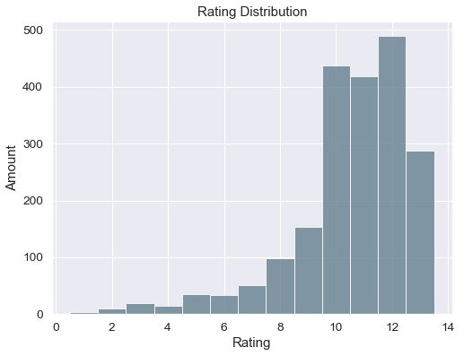

```python
# the distribution of ratings on a histogram
plt.figure(figsize=[8,6])
plt.hist(df['rating_num'], bins=np.arange(0.5, 14.5, 1), alpha=0.8, color='#64818e')
plt.xlabel('Rating')
plt.ylabel('Amount')
plt.title('Rating Distribution');
```

Information about `favorite_count` and `retweet_count`:

```python
# shows descriptive information about favorite counts
df['favorite_count'].describe()
```

```
count      2090.000000
mean       8862.364115
std       12814.740968
min          80.000000
25%        1975.250000
50%        4034.500000
75%       11064.500000
max      165078.000000
Name: favorite_count, dtype: float64
```

```python
# shows descriptive information about retweet counts
df['retweet_count'].describe()
```

```
count     2090.000000
mean      2746.163636
std       4787.423447
min         12.000000
25%        606.500000
50%       1329.500000
75%       3128.500000
max      84382.000000
Name: retweet_count, dtype: float64
```

Trends over time:

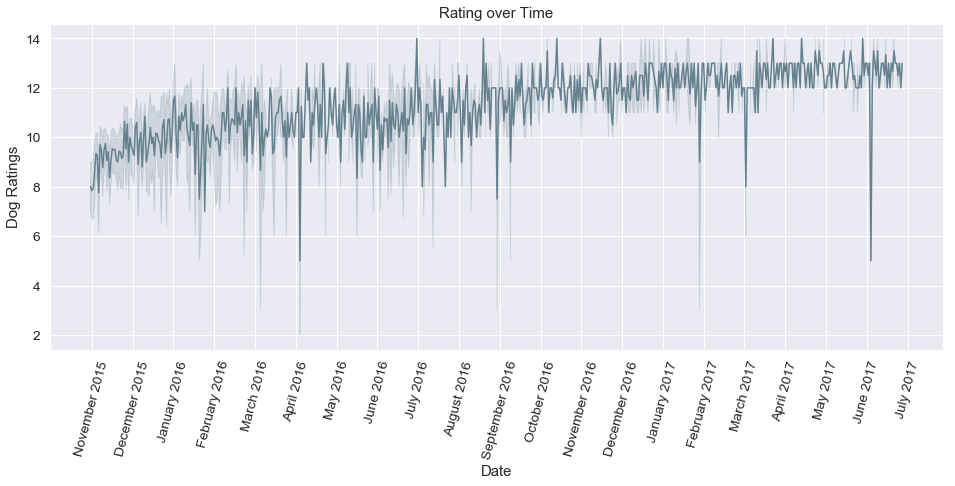

```python
# shows the distribution of ratings over time
import calendar
import warnings
warnings.filterwarnings("ignore")

labels = ([str(i + ' 2015') for i in calendar.month_name[11:13]]
          + [str(i + ' 2016') for i in calendar.month_name[1:13]]
          + [str(i + ' 2017') for i in calendar.month_name[1:8]])

plt.figure(figsize=[16,6])
plt.title('Rating over Time')
plt.xticks(np.arange(1, 645, 30), labels, rotation=75)
ax = sns.lineplot(x='timestamp', y='rating_num', data=df, color='#64818e')
ax.set(xlabel='Date', ylabel='Dog Ratings')
plt.savefig('visuals/rating_over_time.png', bbox_inches='tight')
plt.show();
```

```python
# shows the correlation coefficient
np.corrcoef(list(reversed(df['timestamp'].index.values.astype(float))), df['rating_num'])
```

```
array([[1.       , 0.5359766],
       [0.5359766, 1.       ]])
```

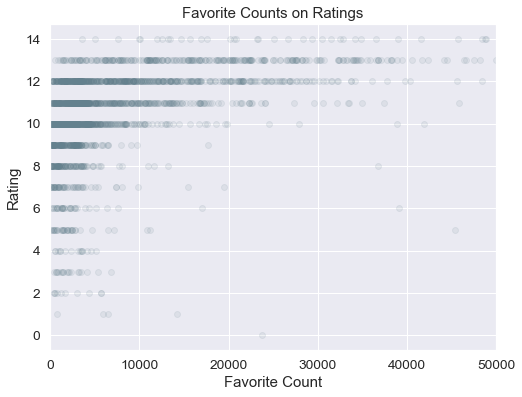

```python
# shows favorite counts over time
plt.figure(figsize=[8,6])
plt.scatter(x=df['favorite_count'], y=df['rating_num'], alpha=0.1, color='#64818e')
plt.xlim(0, 50000)
plt.xlabel('Favorite Count')
plt.ylabel('Rating')
plt.title('Favorite Counts on Ratings');
```

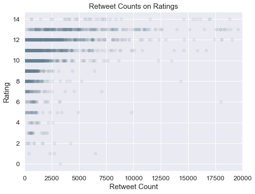

```python
# shows retweet counts over time
plt.figure(figsize=[8,6])
plt.scatter(x=df['retweet_count'], y=df['rating_num'], alpha=0.1, color='#64818e')
plt.xlim(0, 20000)
plt.xlabel('Retweet Count')
plt.ylabel('Rating')
plt.title('Retweet Counts on Ratings');
```

### EDA Conclusion:

The dataset has in total **2091 entries** of dog rate tweets **between November 2015 and August 2017**. The top 3 most represented dog breeds in this dataset are **Golden Retrievers, Labrador Retrievers and Pembroke Corgis**, while **Charlie and Lucy** being the most represented dog names with 11 dog rates each. The rating distribution is **left-skewed** with a **median rating of 11** and an **average rating of 10.598278**. For all of the dataset's tweets, the **average favorite count is 8862** and the **average retweet count is 2746**.

A line plot revealed a trend in the past, where **ratings have become higher over time**. There is a **moderate positive correlation between rating and time**, which can also be derived from the correlaton coefficient of 0.5359766. Scatterplots revealed a positive correlation between the rating of the dog and the favorite count or retweet count.

**Note:** A question to be discussed is, wether the ratings should be normalized for further analysis. It is doubtful to assume that dog's have gotten "better" or "cuter" within a one and a half year time span. The inconsistency of ratings within the dataset would favor more recent dog ratings, and therefore distort the reality. But since the analysis in this project does not aim to give conclusions about the population, no further adjustments will be made at this point.

# Part Va - Asking Questions

1. Which dog breed recieved the highest ratings on average?
2. Which dog stage recieved the highest ratings on average?
3. Which dog breed recieved the highest favorite count on average?
4. Which dog stage recieved the highest favorite count on average?

### 1. Which dog breed recieved the highest ratings on average?

To answer this question, I only included dog breeds in the analysis, which recieved at least 10 different ratings. Any breed category below 10 entries are likely to be coincidential. The assumption is, that certain type of dogs would recieve higher ratings, than others.

```python
# groups the dataset by dog breeds and computes the average rating for each group
breed_groups = df.groupby('breed_pred')['rating_num'].mean()

# filters out dog breed that appear less than 10 times
breed_groups = breed_groups[df['breed_pred'].value_counts() > 10].sort_values(ascending=False)
breed_groups
```

```
breed_pred
eskimo dog                        11.875000
samoyed                           11.725000
chow                              11.641026
golden retriever                  11.532847
great pyrenees                    11.500000
pembroke                          11.409091
siberian husky                    11.315789
bernese mountain dog              11.272727
cardigan                          11.250000
cocker spaniel                    11.240000
french bulldog                    11.222222
rottweiler                        11.187500
pomeranian                        11.166667
pekinese                          11.166667
labrador retriever                11.118280
toy poodle                        11.054054
german shepherd                   11.000000
kuvasz                            11.000000
malamute                          11.000000
american staffordshire terrier    11.000000
shih tzu                          10.866667
vizsla                            10.833333
miniature pinscher                10.777778
shetland sheepdog                 10.750000
basset                            10.733333
chihuahua                         10.702703
chesapeake bay retriever          10.681818
west highland white terrier       10.666667
staffordshire bullterrier         10.666667
border collie                     10.583333
beagle                            10.375000
lakeland terrier                  10.285714
pug                               10.264151
airedale                          10.181818
italian greyhound                  9.833333
maltese dog                        9.500000
Name: rating_num, dtype: float64
```

Plotting a horizontal bar chart with `breed_groups`

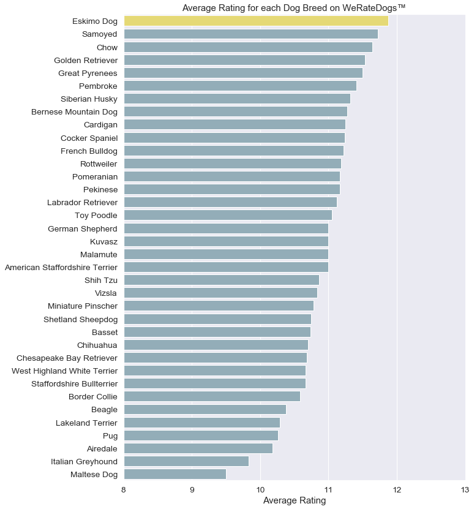

```python
# define axis values
x_axis = list(breed_groups)
y_axis = [i.title() for i in breed_groups.index]

# plot the bar chart
plt.figure(figsize=[10,14])
plt.xlim(8,13)
plt.xlabel('Average Rating')
plt.title('Average Rating for each Dog Breed on WeRateDogs™')
colors = ['#8dafbe' if (x < max(x_axis)) else '#f8e863' for x in x_axis]
ax = sns.barplot(x=x_axis, y=y_axis, label=y_axis, color="b", palette=colors)
plt.savefig('visuals/rating_each_breed.png', bbox_inches='tight')
plt.show();
```

### Answer:

**Eskimo dogs** recieved the highest ratings on WeRateDogs with an **average rating of 11.875**, followed by **Samoyeds with an average rating of 11.725** and **Chows with an average rating of 11.641**.

### 2. Which dog stage recieved the highest ratings on average?

```python
# puts floofs and floofers into the same category 'floof'
df['stage'] = df['stage'].replace('floofer', 'floof')
```

```python
# groups the dataset by dog stages and computes the average rating for each group
stage_groups = df.groupby('stage')['rating_num'].mean()

# sorts the stage groups by descending order
stage_groups = stage_groups.sort_values(ascending=False)
stage_groups
```

```
stage
puppo     12.107143
doggo     11.725275
floof     11.694444
pupper    10.688525
Name: rating_num, dtype: float64
```

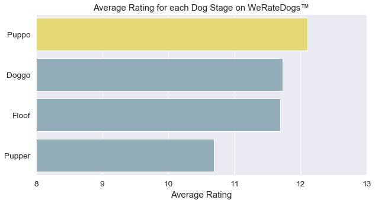

```python
# define axis values
x_axis = list(stage_groups)
y_axis = [i.title() for i in stage_groups.index]

# plot the bar chart
plt.figure(figsize=[10,5])
plt.xlim(8,13)
plt.xlabel('Average Rating')
plt.title('Average Rating for each Dog Stage on WeRateDogs™')
colors = ['#8dafbe' if (x < max(x_axis)) else '#f8e863' for x in x_axis]
ax = sns.barplot(x=x_axis, y=y_axis, label=y_axis, color="b", palette=colors)
plt.savefig('visuals/rating_each_stage.png', bbox_inches='tight')
plt.show();
```

### Answer:

**Puppo's**, which is a term for teenage dogs, recieved the highest ratings on WeRateDogs with an **average rating of 12.107**, while **pupper's**, which basically are puppies, recieved the **lowest ratings with an average rating of 10.689**.

### 3. Which dog breed recieved the highest favorite counts on average?

```python
# groups the dataset by dog breeds and computes the average favorite count for each group
breed_groups_fav = df.groupby('breed_pred')['favorite_count'].mean()

# filters out dog breed that appear less than 10 times
breed_groups_fav = breed_groups_fav[df['breed_pred'].value_counts() > 10].sort_values(ascending=False)
breed_groups_fav
```

```
breed_pred
french bulldog                    17949.038462
eskimo dog                        15911.750000
cardigan                          14303.875000
samoyed                           14001.300000
great pyrenees                    12451.785714
labrador retriever                11998.677419
golden retriever                  11963.686131
basset                            11832.400000
cocker spaniel                    11812.800000
malamute                          11729.482759
pembroke                          11212.772727
chesapeake bay retriever          10640.045455
italian greyhound                 10231.833333
staffordshire bullterrier          9893.888889
german shepherd                    9806.550000
chow                               9802.871795
chihuahua                          8951.986486
border collie                      8653.750000
shetland sheepdog                  8317.562500
miniature pinscher                 8210.555556
rottweiler                         7768.625000
pekinese                           7371.500000
american staffordshire terrier     7291.076923
west highland white terrier        7166.833333
vizsla                             7063.833333
bernese mountain dog               7046.636364
siberian husky                     6939.052632
pomeranian                         6762.750000
toy poodle                         6535.405405
pug                                5723.301887
kuvasz                             5679.142857
airedale                           5437.363636
beagle                             4666.437500
lakeland terrier                   4500.000000
shih tzu                           4122.866667
maltese dog                        2938.625000
Name: favorite_count, dtype: float64
```

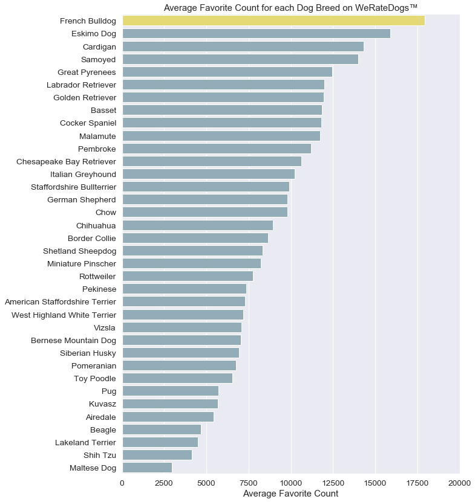

```python
# define axis values
x_axis = list(breed_groups_fav)
y_axis = [i.title() for i in breed_groups_fav.index]

# plot the bar chart
plt.figure(figsize=[10,14])
plt.xlim(0, 20000)
plt.xlabel('Average Favorite Count')
plt.title('Average Favorite Count for each Dog Breed on WeRateDogs™')
colors = ['#8dafbe' if (x < max(x_axis)) else '#f8e863' for x in x_axis]
ax = sns.barplot(x=x_axis, y=y_axis, label=y_axis, color="b", palette=colors)
plt.show();
```

### Answer:

Regarding the popularity of dog breeds, **French Bulldogs have scored the highest** between all dog breeds with an **average favorite count of 17949 per tweet**, contrary to the average ratings, in which they only placed 11th. The second most popular dog breed on WeRateDogs is the **Eskimo Dog with an average favorite counnt of 15911 per tweet**, which also placed 1st on the average rating chart.

### 4. Which dog stage recieved the highest favorite count on average?

```python
# groups the dataset by dog stages and computes the average favorite count for each group
stage_groups_fav = df.groupby('stage')['favorite_count'].mean()

# sorts the stage groups by descending order
stage_groups_fav = stage_groups_fav.sort_values(ascending=False)
stage_groups_fav
```

```
stage
puppo     22091.857143
doggo     17623.032967
floof      8518.222222
pupper     6948.307377
Name: favorite_count, dtype: float64
```

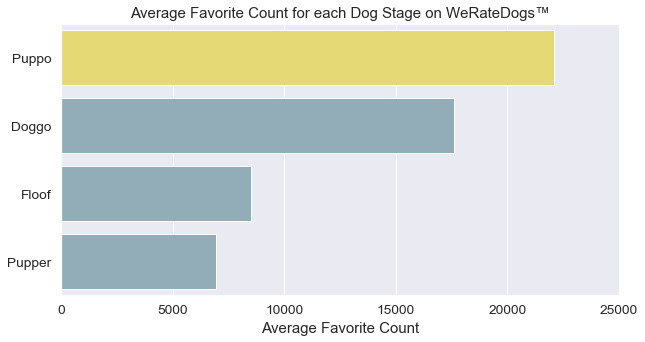

```python
# define axis values
x_axis = list(stage_groups_fav)
y_axis = [i.title() for i in stage_groups_fav.index]

# plot the bar chart
plt.figure(figsize=[10,5])
plt.xlim(0,25000)
plt.xlabel('Average Favorite Count')
plt.title('Average Favorite Count for each Dog Stage on WeRateDogs™')
colors = ['#8dafbe' if (x < max(x_axis)) else '#f8e863' for x in x_axis]
ax = sns.barplot(x=x_axis, y=y_axis, label=y_axis, color="b", palette=colors)
plt.show();
```

### Answer:

**Puppos** have recieved the **most favorite counts (or "likes")** on average between the other dog stages, with an average favorite count of **22091 per tweet**. This makes puppos not only the highest rated dog stage, but also the most popular within the WeRateDogs community in the observed time period.

# Part Vb - Additional Visualizations

To convert the charts of the last chapter into interesting visualizations, a word cloud has been framed onto a picture of each sections highest placing dogs in addition to their key metrics.

For this task, following steps have been made:

- Parse all the texts for each group, eskimo dogs, french bulldogs, and puppos
- Generate a word cloud frame for each observation using Andreas Mueller's wordcloud package for python.
- Merge appropriate images with the word clouds using photoshop.

```python
# Parse texts for Question 1
import re
q1_text = str()
for i in df[df['breed_pred'] == 'eskimo dog'].text:
    q1_text += re.search('(.*)[^http.-{}]', i).group(0)

# Parse texts for Question 2 & 4
q24_text = str()
for i in df[df['stage'] == 'puppo'].text:
    q24_text += re.search('(.*)[^http.-{}]', i).group(0)

# Parse texts for Question 3
q3_text = str()
for i in df[df['breed_pred'] == 'french bulldog'].text:
    q3_text += re.search('(.*)[^http.-{}]', i).group(0)
```

```python
# Import packages for the wordcloud
from os import path
from PIL import Image
import os

from wordcloud import WordCloud, STOPWORDS
```

```python
# get data directory
d = path.dirname(__file__) if "__file__" in locals() else os.getcwd()
```

```python
# read the mask
doggy_mask = np.array(Image.open(path.join(d, "visuals/doggymask.png")))

stopwords = set(STOPWORDS)
stopwords.add("said")

wc = WordCloud(background_color="#e6e6e6", min_font_size=10, max_font_size=70
               , max_words=4000, mask=doggy_mask, stopwords=stopwords)
```

```python
# generate word cloud and store for each category
wc.generate(q1_text)
wc.to_file(path.join(d, "visuals/eskimo_cloud.png"))

wc.generate(q24_text)
wc.to_file(path.join(d, "visuals/puppo_cloud.png"))

wc.generate(q3_text)
wc.to_file(path.join(d, "visuals/frenchy_cloud.png"))
```

```
<wordcloud.wordcloud.WordCloud at 0x1d46d701a20>
```

# The Word Cloud results (after Photoshop), because why not?

### Dog Breed with Highest Average Rating:

[figure not shown]

### Dog Breed with Highest Average Favorite Count:

[figure not shown]

### Dog Stage with Highest Rating and Favorite Count:

[figure not shown]

### Summary

To achieve the goals of the analysis, data have been gathered from different sources, including the twitter api as well as other web data. The potentials of Python's pandas library has been used extensively on the assessment and data cleaning parts. For the conclusion part, statements regarding the performance of each dog breed and dog stage (age group) have been given. To sum up the conclusions, visualizations in forms of word clouds have been plotted in accordance to the observations.